# C4P Presentation

Conor Tompkins

April 13, 2019

## Packages

- Simple Features {sf}
- {tidycensus}
- {ggmap}

Get your census API key: https://api.census.gov/data/key_signup.html

Configure environment:

```r
library(tidycensus)
library(tidyverse)
library(sf)
library(tigris)
library(lwgeom)
library(ggmap)
library(janitor)

theme_set(theme_bw())

options(tigris_use_cache = TRUE,
        scipen = 4,
        digits = 3)
```

### {tidycensus}

[`tidycensus`](https://walkerke.github.io/tidycensus/) gives access to census API and makes it easy to plot data on a map.

Data

- Demographics
  - Decennial Census
  - American Community Survey (ACS)
- Geometries
  - country
  - county
  - zip code
  - blocks
  - tracts

### {sf}

[simple features](https://r-spatial.github.io/sf/articles/sf1.html) makes it easy to work with polygon data in R. It uses familiar the `tidyverse` framework: everything is a tibble, and it uses `%>%`

### {ggmap}

Uses [Google Maps API](https://cloud.google.com/maps-platform/) to get basemaps.

#### Using {tidycensus}

Load ACS variables:

```r
variables_acs <- load_variables(2017, "acs5", cache = TRUE)
```

| name | label | concept |
| --- | --- | --- |
| B00001_001 | Estimate!!Total | UNWEIGHTED SAMPLE COUNT OF THE POPULATION |
| B00002_001 | Estimate!!Total | UNWEIGHTED SAMPLE HOUSING UNITS |
| B01001_001 | Estimate!!Total | SEX BY AGE |
| B01001_002 | Estimate!!Total!!Male | SEX BY AGE |
| B01001_003 | Estimate!!Total!!Male!!Under 5 years | SEX BY AGE |

Load Decennial Census data:

```r
variables_dec <- load_variables(2010, "sf1", cache = TRUE)
```

| name | label | concept |
| --- | --- | --- |
| H001001 | Total | HOUSING UNITS |
| H002001 | Total | URBAN AND RURAL |
| H002002 | Total!!Urban | URBAN AND RURAL |
| H002003 | Total!!Urban!!Inside urbanized areas | URBAN AND RURAL |
| H002004 | Total!!Urban!!Inside urban clusters | URBAN AND RURAL |

Plot the total population of the continental U.S. states:

```r
states <- get_decennial(geography = "state",
                           variables = c(total_pop = "P001001"),
                           geometry = TRUE,
                        output = "wide")
```

Examine the `states` tibble:

```
## Simple feature collection with 52 features and 3 fields
## geometry type:  MULTIPOLYGON
## dimension:      XY
## bbox:           xmin: -179 ymin: 17.9 xmax: 180 ymax: 71.4
## epsg (SRID):    4269
## proj4string:    +proj=longlat +datum=NAD83 +no_defs
## # A tibble: 52 x 4
##    GEOID NAME     total_pop                                        geometry
##    <chr> <chr>        <dbl>                              <MULTIPOLYGON [°]>
##  1 01    Alabama    4779736 (((-85 31, -85 31, -85 31, -85 31, -85 31, -85~
##  2 02    Alaska      710231 (((-165 54.1, -165 54.1, -165 54.1, -165 54.1,~
##  3 04    Arizona    6392017 (((-109 37, -109 37, -109 37, -109 36.9, -109 ~
##  4 05    Arkansas   2915918 (((-94.6 36.5, -94.5 36.5, -94.4 36.5, -94.1 3~
##  5 06    Califor~  37253956 (((-122 37.9, -122 37.9, -122 37.9, -122 37.9,~
##  6 22    Louisia~   4533372 (((-88.9 29.8, -88.9 29.7, -88.9 29.7, -88.9 2~
##  7 21    Kentucky   4339367 (((-83.7 36.6, -83.7 36.6, -83.7 36.6, -83.7 3~
##  8 08    Colorado   5029196 (((-102 37, -102 37, -102 37, -102 37, -102 37~
##  9 09    Connect~   3574097 (((-71.9 41.3, -71.9 41.3, -71.9 41.3, -71.9 4~
## 10 10    Delaware    897934 (((-75.6 39.6, -75.6 39.6, -75.6 39.6, -75.6 3~
## # ... with 42 more rows
```

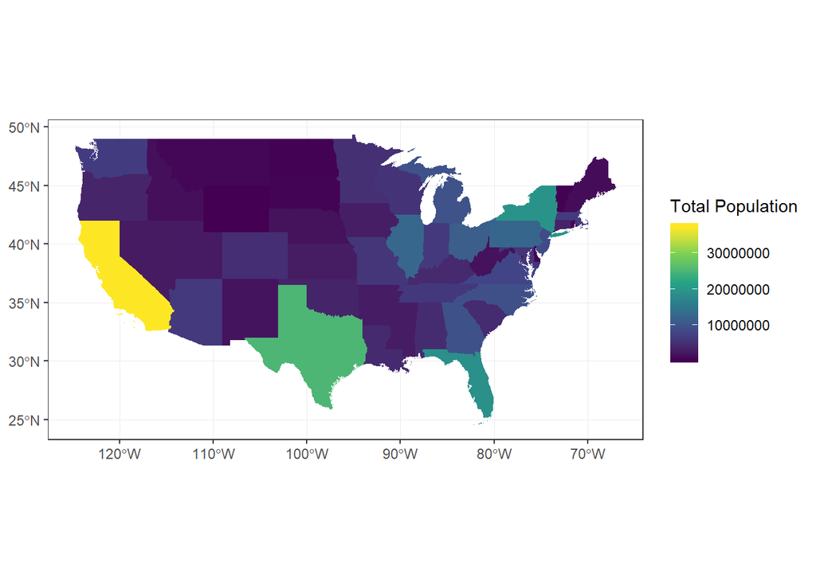

```r
states %>%
  filter(NAME != "Alaska",
         NAME != "Hawaii",
         !str_detect(NAME, "Puerto")) %>%
  ggplot(aes(fill = total_pop)) +
  geom_sf(color = NA) +
  scale_fill_viridis_c("Total Population")
```

Plot the total population of each county in PA:

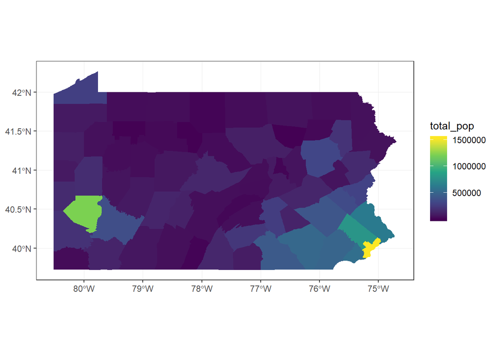

```r
pennsylvania <- get_decennial(geography = "county",
                           variables = c(total_pop = "P001001"),
                           state = "PA",
                           geometry = TRUE,
                           output = "wide")

pennsylvania %>%
  ggplot(aes(fill = total_pop)) +
  geom_sf(color = NA) +
  scale_fill_viridis_c()
```

Highlight Allegheny County:

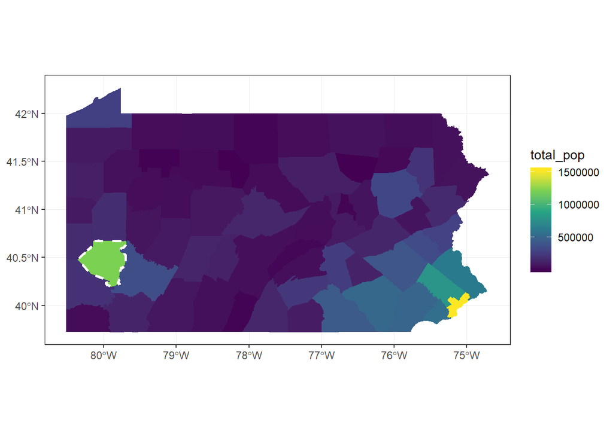

```r
allegheny <- pennsylvania %>%
  filter(str_detect(NAME, "Allegheny"))

pennsylvania %>%
  ggplot() +
  geom_sf(aes(fill = total_pop), color = NA) +
  geom_sf(data = allegheny, color = "white", linetype = 2, size = 1, alpha = 0) +
  scale_fill_viridis_c()
```

don’t use load census block data for total pop

don’t use graph

We can also use `tidycensus` to download demographic data for census tracts.

Set the variables we want to use first:

```r
racevars <- c(White = "P005003",
              Black = "P005004",
              Asian = "P005006",
              Hispanic = "P004003")

#note that this data is long, not wide
allegheny <- get_decennial(geography = "tract", variables = racevars,
                        state = "PA", county = "Allegheny County", geometry = TRUE,
                        summary_var = "P001001")
```

Calculate as a percentage of tract population:

```r
allegheny <- allegheny %>%
  mutate(pct = 100 * value / summary_value)
```

Facet by `variable` and map the data:

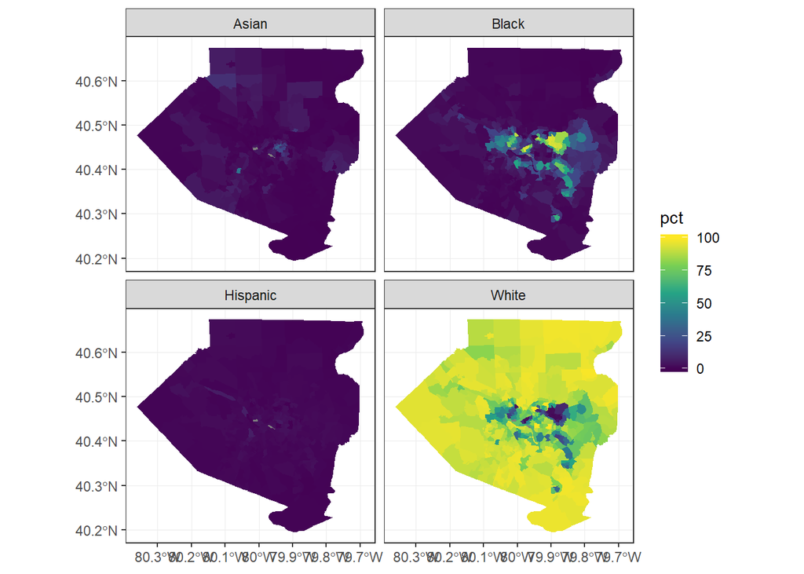

```r
allegheny %>%
  ggplot(aes(fill = pct)) +
  geom_sf(color = NA) +
  facet_wrap(~variable) +
  scale_fill_viridis_c()
```

make rivers show up

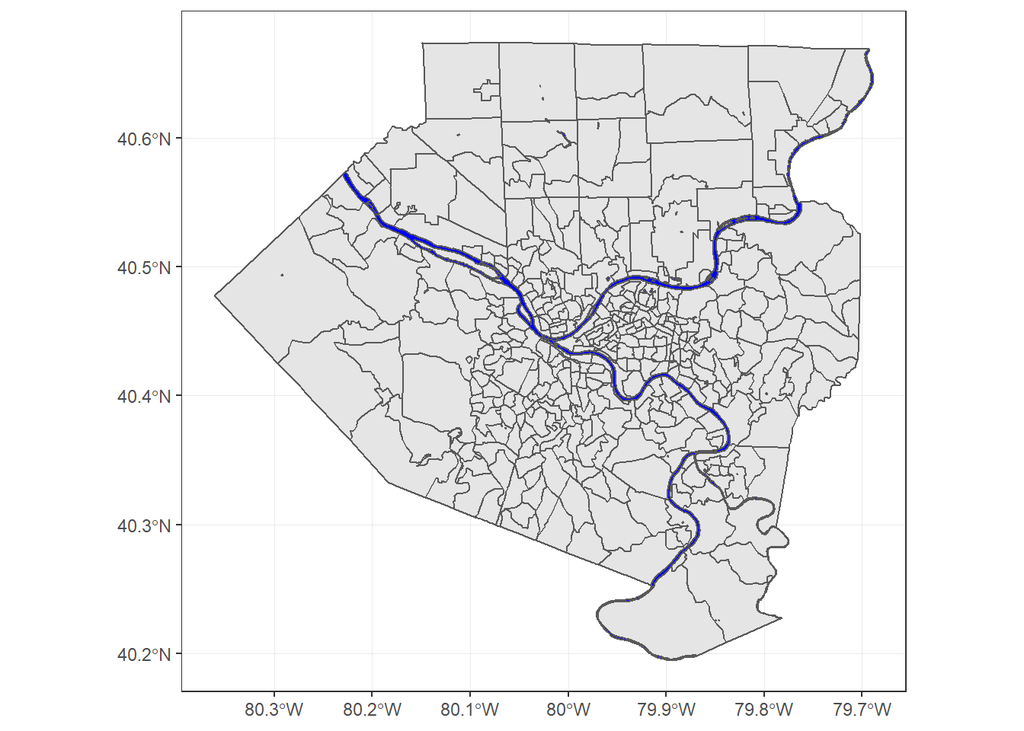

```r
st_erase <- function(x, y) {
  st_difference(x, st_union(st_combine(y)))
}

allegheny_water <- area_water("PA", "Allegheny County", class = "sf")

allegheny %>%
  ggplot() +
  geom_sf() +
  geom_sf(data = allegheny_water, fill = "blue")
```

```r
#allegheny_erase <- st_erase(allegheny, allegheny_water)
```

We can overlay the boundaries of Pittsburgh over the same graph.

Download the [boundary shapefile](https://catalog.data.gov/dataset/pittsburgh-city-boundary-cbe8f) and use `sf::st_read` to read it into R:

```r
city_pgh <- st_read("Pittsburgh_City_Boundary/Pittsburgh_City_Boundary.shp")
```

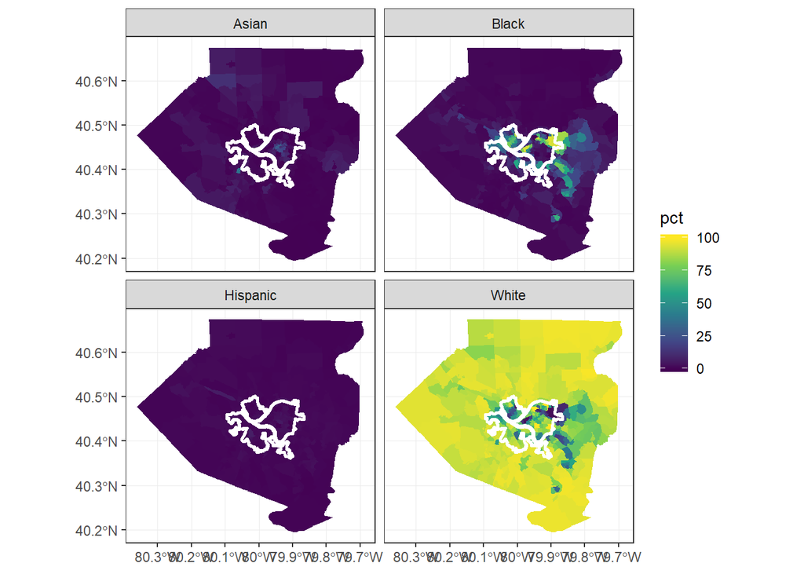

```r
allegheny %>%
  ggplot() +
  geom_sf(aes(fill = pct), color = NA) +
  geom_sf(data = city_pgh, color = "white", line_type = 2, size = 1, alpha = 0) +
  facet_wrap(~variable) +
  scale_fill_viridis_c()
```

WPRDC fire data

#### 311 data and city wards

We can also download the shapefile for the [City of Pittsburgh wards](https://catalog.data.gov/dataset/pittsburgh-wards). The [311 dataset](https://data.wprdc.org/dataset/311-data/resource/76fda9d0-69be-4dd5-8108-0de7907fc5a4) is tagged with the ward the request originated from, so we can use that to aggregate and map the total number of 311 requests per ward.

```r
df_311 <- read_csv("https://data.wprdc.org/datastore/dump/76fda9d0-69be-4dd5-8108-0de7907fc5a4")

wards <- st_read("PGHWards/PGHWards.shp")
```

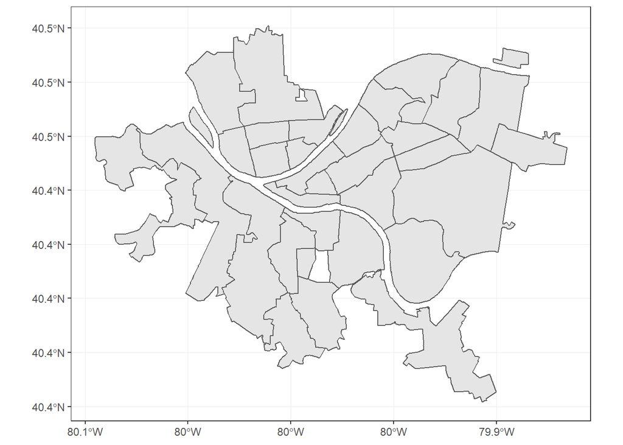

```r
wards %>%
  ggplot() +
  geom_sf()
```

Calculate the center of each ward. We will use this to label the wards on the map:

```r
ward_labels <- wards %>%
  st_centroid() %>%
  st_coordinates() %>%
  as_tibble() %>%
  clean_names()
```

| x | y |
| --- | --- |
| -80 | 40.4 |
| -80 | 40.5 |
| -80 | 40.5 |
| -80 | 40.4 |
| -80 | 40.5 |

Count the number of requests per ward:

```r
df_311_count <- df_311 %>%
  count(WARD, sort = TRUE)
```

Join the count data with the coordinates:

```r
ward_311 <- wards %>%
  left_join(df_311_count, by = c("ward" = "WARD")) %>%
  bind_cols(ward_labels)
```

```
## Simple feature collection with 35 features and 10 fields
## geometry type:  POLYGON
## dimension:      XY
## bbox:           xmin: -80.1 ymin: 40.4 xmax: -79.9 ymax: 40.5
## epsg (SRID):    4326
## proj4string:    +proj=longlat +datum=WGS84 +no_defs
## First 10 features:
##    objectid wards_ wards_id ward wardtext Shape__Are Shape__Len     n
## 1         2      3        0   19       19  0.0011446     0.2389 27004
## 2         3      4        0   24       24  0.0001901     0.0734  5288
## 3         4      5        0   24       24  0.0000210     0.0274  5288
## 4         5      6        0   20       20  0.0011755     0.2888 17172
## 5         6      7        0   21       21  0.0002074     0.0619  3788
## 6         7      8        0   23       23  0.0001031     0.0480  4979
## 7         8      9        0   22       22  0.0001967     0.0593  4591
## 8         9     10        0   26       26  0.0009079     0.1915 10927
## 9        10     11        0   27       27  0.0005849     0.1173 10031
## 10       11     12        0   27       27  0.0000634     0.0400 10031
##                          geometry   x    y
## 1  POLYGON ((-80 40.4, -80 40.... -80 40.4
## 2  POLYGON ((-80 40.5, -80 40.... -80 40.5
## 3  POLYGON ((-80 40.5, -80 40.... -80 40.5
## 4  POLYGON ((-80 40.4, -80 40.... -80 40.4
## 5  POLYGON ((-80 40.5, -80 40.... -80 40.5
## 6  POLYGON ((-80 40.5, -80 40.... -80 40.5
## 7  POLYGON ((-80 40.5, -80 40.... -80 40.5
## 8  POLYGON ((-80 40.5, -80 40.... -80 40.5
## 9  POLYGON ((-80 40.5, -80 40.... -80 40.5
## 10 POLYGON ((-80 40.5, -80 40.... -80 40.5
```

Plot the data:

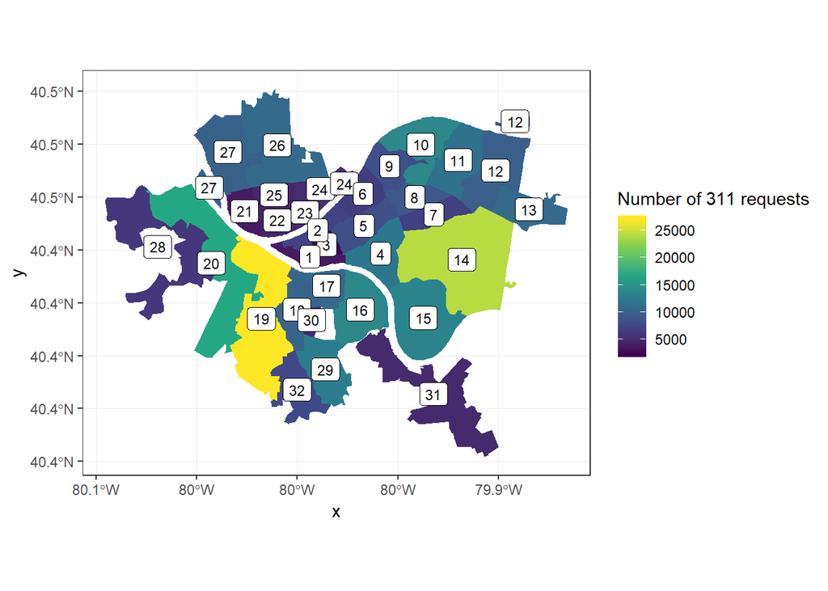

```r
ward_311 %>%
  ggplot() +
  geom_sf(aes(fill = n), color = NA) +
  geom_label(aes(x, y, label = ward), size = 3) +
  scale_fill_viridis_c("Number of 311 requests")
```

We can use `ggmap` to request a basemap from the Google Maps API. Get your API key [here](https://cloud.google.com/maps-platform/)

```r
register_google(key = "Your key here")
```

[figure not shown]

```r
pgh_map <- get_map(location = "Pittsburgh, PA", zoom = 12)

ggmap(pgh_map)
```

Combining maps from different systems requires us to use the same map projection. Use `coord_sf` to set the projection:

[figure not shown]

```r
ggmap(pgh_map) +
  geom_sf(data = ward_311, aes(fill = n), inherit.aes = FALSE, color = NA, alpha = .7) +
  geom_label(data = ward_311, aes(x, y, label = ward), size = 3) +
  coord_sf(crs = st_crs(4326)) +
  scale_fill_viridis_c("Number of 311 requests")
```

## Links

- https://walkerke.github.io/tidycensus/articles/basic-usage.html
- https://walkerke.github.io/tidycensus/reference/get_acs.html
- https://walkerke.github.io/tidycensus/articles/spatial-data.html
- https://walkerke.github.io/tidycensus/articles/other-datasets.html
- https://cengel.github.io/R-spatial/mapping.html
- https://www.r-spatial.org/r/2018/10/25/ggplot2-sf.html
- https://www.r-spatial.org/r/2018/10/25/ggplot2-sf-2.html
- https://www.r-spatial.org/r/2018/10/25/ggplot2-sf-3.html
- google maps API key: https://cloud.google.com/maps-platform/
- https://lucidmanager.org/geocoding-with-ggmap/